# Régression non-paramétrique

#### 3.2.2. La densitée x->$\mu$(x) peut-elle etre gaussienne ?

Proposer un protocole pour le verifier empiriquement et l’implementer. On pourra penser a renormaliser ksi par la fonction estimee a la question precedente et s’aider des questions de la Section 3.1.

http://www.biostat.ulg.ac.be/pages/Site_r/Normalite.html

- 1- test du QQPlot

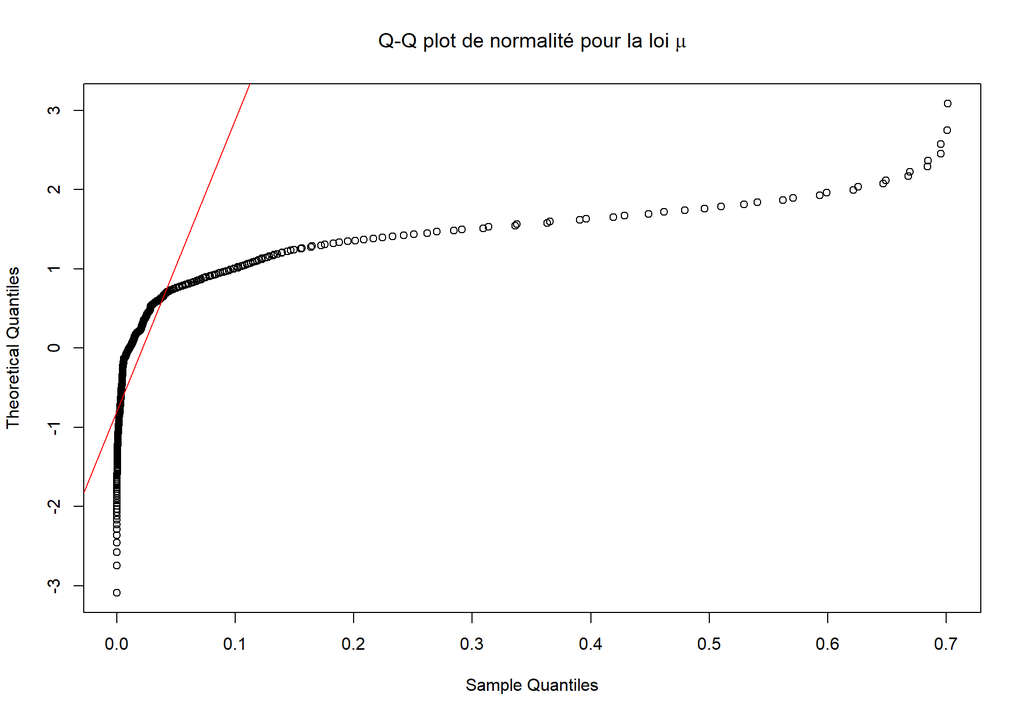

[figure not shown]

  => non ou bien gaussien par morceau
- 2- test de shapiro

```r
 shapiro.test(mu_hDpill$y)
```

```
##
##  Shapiro-Wilk normality test
##
## data:  mu_hDpill$y
## W = 0.49198, p-value < 2.2e-16
```

Le test de Shapiro-Wilk donne une probabilité de dépassement de p-value < 2.2e-16, nettement < à 0.05. L’hypothèse de normalité est rejettéee.

- 3- test de Kolmogorov-Smirnoff Dans ce cas-ci également, il existe dans R une commande pour tester l’ajustement de données à une loi normale via le test de Kolmogorov-Smirnov:

```r
 ks.test(mu_hDpill$y,"pnorm",mean(mu_hDpill$y),sd(mu_hDpill$y))
```

```
##
##  One-sample Kolmogorov-Smirnov test
##
## data:  mu_hDpill$y
## D = 0.32364, p-value < 2.2e-16
## alternative hypothesis: two-sided
```

p-value faible rejetté

#### Raffinement pour h: 0.4 - 0.5

[output not shown]

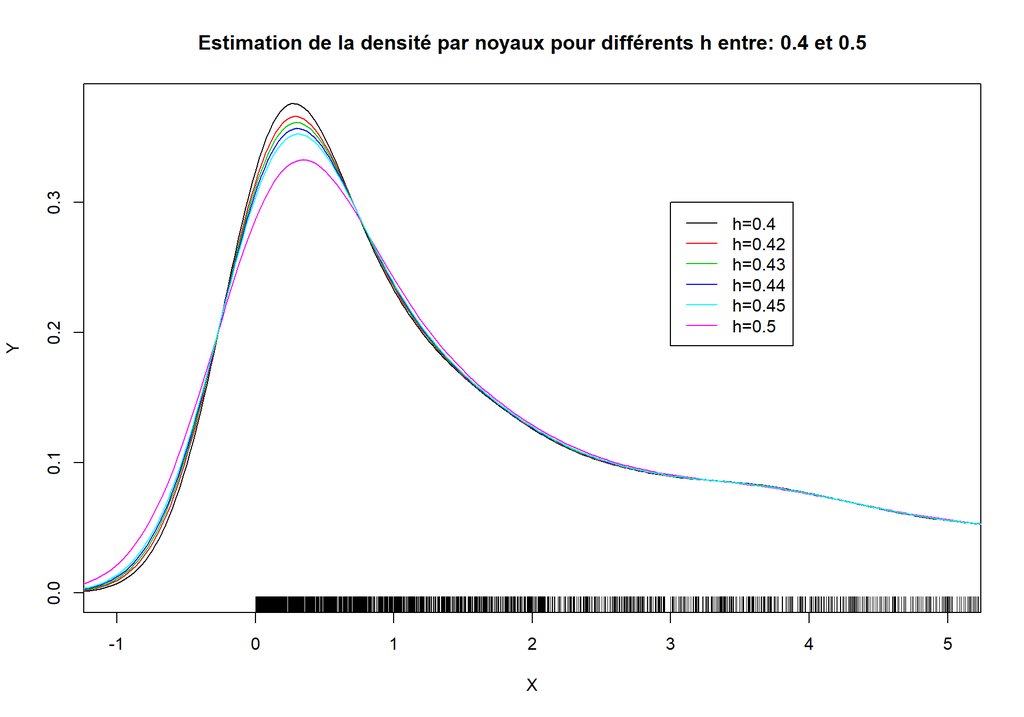

Les estimations de la tensité g(x) de X pour des valeurs de h comprise entre 0.4 et 0.5 sont très proches. A ce niveau il est difficile de déterminer empiriquement le h optimal.